# Assignment 04

Author

Alex Stout and Rachel Schneider

Data: https://www.pewresearch.org/politics/dataset/2014-political-polarization-survey/

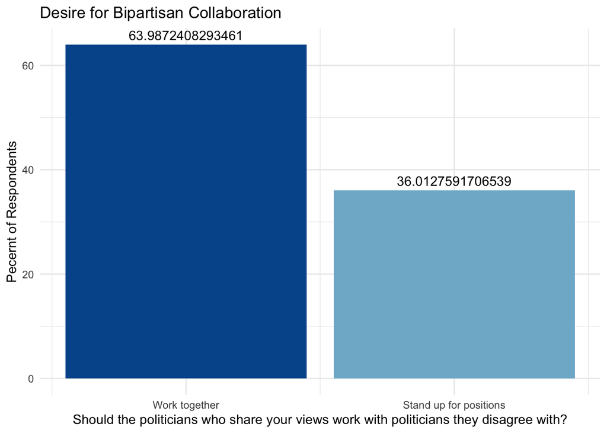

```r
library(haven)
library(ggplot2)
library(dplyr)

# Load Data
data <- read_sav("data/Polarization 2014 public.sav")

# Bar Chart Visualization 1

# Select columns and remove missing values
count_data <- data %>%
  select(qb12) %>%
  na.omit()

# Count the number of respondents by answer to qb12
count_data <- count_data %>%
  group_by(qb12) %>%
  summarize(count = n())

# Calculate the percentage of respondents by party and ideology
percent_data <- count_data %>%
  group_by(qb12) %>%
  mutate(percent = count/3135*100)

# Create bar chart
ggplot(subset(percent_data, qb12 <= 2), aes(x = qb12, y = percent, fill = factor(qb12))) +
  geom_bar(stat = "identity", position = "dodge") +
  labs(title = "Desire for Bipartisan Collaboration") +
  xlab("Should the politicians who share your views work with politicians they disagree with?") +
  ylab("Pecernt of Respondents") +
  geom_text(aes(label = percent), position = position_dodge(width = 0.9), vjust = -0.5) +
  scale_x_continuous(
    breaks = c(1, 2),
    labels = c("Work together", "Stand up for positions")
  ) +
  scale_fill_manual(values = c("#00569B", "#80B6D1")) +
  theme_minimal() +
  guides(fill = FALSE)
```

This bar graph displays responses to the question “Thinking about elected officials in Washington who share your positions on the most important issues facing the nation. 1 Should they work with elected officials they disagree with, even if it results in some policies you don’t like [OR] 2 Should they stand up for their positions, even if that means little gets done in Washington”. The x-axis shows the response options and the y-axis shows the percentage of people with that response. We can see from the graph that a majority (over 60% of respondents) think the politicians they agree with should work together with those they do not agree with. This is interesting considering the results of the following graph which shows that a plurality of people think there is a great deal of difference between the republican and democratic parties.

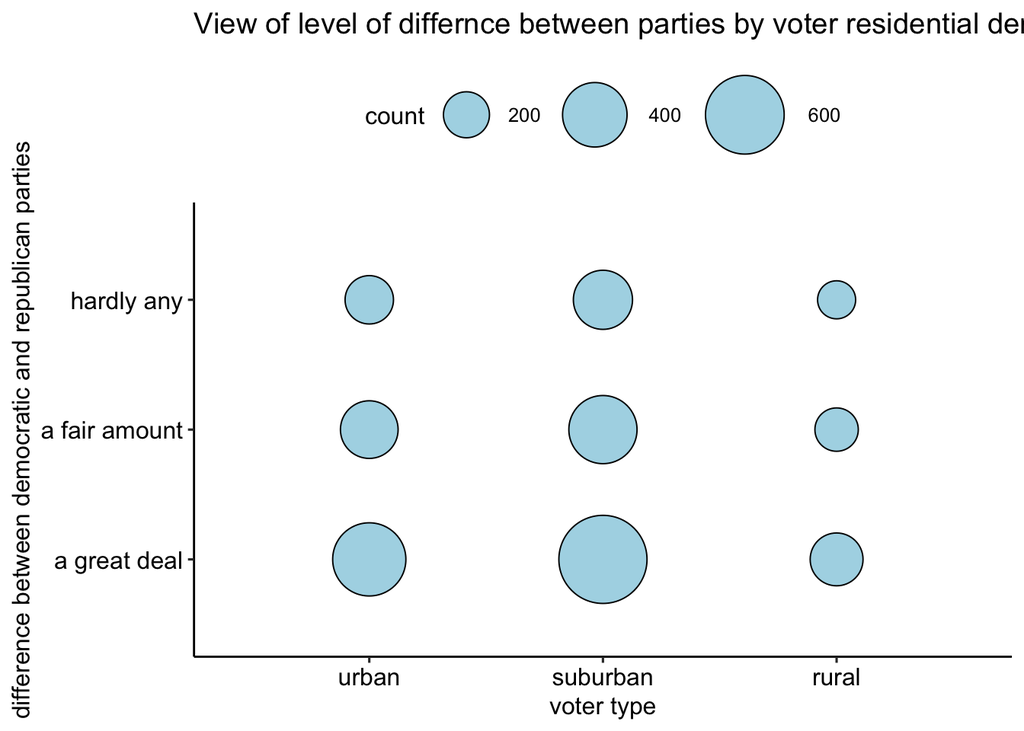

```r
library(ggplot2)
library(ggpubr)
theme_set(theme_pubr())

# Create visualization

data("data")

# create balloon chart

# Select columns and remove missing values
count_dataq5 <- data %>%
  select(qb5, usr) %>% filter(usr == "U" | usr == "S" | usr == "R") %>%
  na.omit()

# Count the number of respondents by answer to qb5
count_dataq5 <- count_dataq5 %>%
  group_by(qb5, usr) %>%
  summarize(count = n())

# Create a scatter plot with circle size proportional to count
cdat_sp <- ggplot(subset(count_dataq5, qb5 <= 3), aes(x = factor(usr), y = factor(qb5), size = count)) +
  geom_point(shape = 21, colour = "black", fill = "light blue")

# Set the factor levels to include in the x-axis
usr_levels <- c("U", "S", "R")

# Set the factor levels to include in the y-axis
qb5_levels <- c(1:3)

# map to area and make circles larger
cdat_sp + scale_size_area(max_size = 20) +
  labs(title = "View of level of differnce between parties by voter residential demographic") +
  scale_x_discrete(limits = usr_levels, expand = c(0.25, 0.25), labels = c("urban", "suburban", "rural")) +
  scale_y_discrete(limits = qb5_levels, expand = c(0.25, 0.25), labels = c("a great deal", "a fair amount","hardly any")) +
  labs(x = "voter type", y = "difference between democratic and republican parties")
```

This bubble plot displays the answers to the question “Thinking about the Democratic and Republican parties, would you say there is a great deal of difference in what they stand for, a fair amount of difference, or hardly any difference at all?”. The answers are displayed by type of area the respondent lives in (either urban, suburban, or rural). This visualization is interesting as it shows the differences in responses by type of area people live in and also displays that, despite a majority of people thinking politicians should work together with those they disagree with, a majority also think there is either “a great deal” or “a fair amount” of difference between the parties.

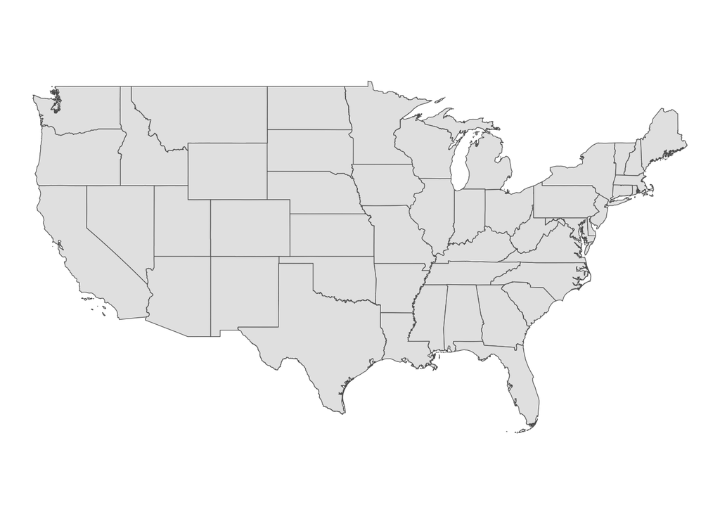

```r
library(ggplot2)
library(dplyr)
library(sf)
library(tigris)
library(stringr)

# Creating the Map of the US

map <- tigris:: states(cb = TRUE, progress_bar = FALSE) %>%
  filter(!STATEFP %in% c("78", "69", "66", "60", "72", "02", "15"))

map %>%
  ggplot() +
  geom_sf() +
  theme_void()
```

```r
# Cleaning and Combining Data

(vis01 <- data %>%
    filter(qb2 != 9, !is.na(qb2))%>%
    mutate(state = str_pad(state, side = "left", pad = "0", width = 2)) %>%
    select(state, respid, qb2) %>%
    rename(STATEFP = state) %>%
    group_by(STATEFP, qb2) %>%
    summarize(qb_count = n())
)
```

```
# A tibble: 102 × 3
# Groups:   STATEFP [51]
   STATEFP qb2              qb_count
   <chr>   <dbl+lbl>           <int>
 1 01      1 [Satisfied]          13
 2 01      2 [Dissatisfied]       42
 3 02      1 [Satisfied]           4
 4 02      2 [Dissatisfied]        5
 5 04      1 [Satisfied]          20
 6 04      2 [Dissatisfied]       54
 7 05      1 [Satisfied]           4
 8 05      2 [Dissatisfied]       30
 9 06      1 [Satisfied]         127
10 06      2 [Dissatisfied]      186
# … with 92 more rows
```

```r
(state_total <- data %>%
    filter(qb2 != 9, !is.na(qb2))%>%
    mutate(state = str_pad(state, side = "left", pad = "0", width = 2)) %>%
    select(state, respid, qb2) %>%
    rename(STATEFP = state) %>%
    group_by(STATEFP) %>%
    summarize(state_count = n())
)
```

```
# A tibble: 51 × 2
   STATEFP state_count
   <chr>         <int>
 1 01               55
 2 02                9
 3 04               74
 4 05               34
 5 06              313
 6 08               52
 7 09               33
 8 10               15
 9 11               13
10 12              187
# … with 41 more rows
```

```r
(vis01 <- left_join(state_total, vis01, by = "STATEFP") %>%
  mutate(percent = qb_count/state_count) %>%
    filter(qb2 != 2)
)
```

```
# A tibble: 51 × 5
   STATEFP state_count qb2           qb_count percent
   <chr>         <int> <dbl+lbl>        <int>   <dbl>
 1 01               55 1 [Satisfied]       13  0.236
 2 02                9 1 [Satisfied]        4  0.444
 3 04               74 1 [Satisfied]       20  0.270
 4 05               34 1 [Satisfied]        4  0.118
 5 06              313 1 [Satisfied]      127  0.406
 6 08               52 1 [Satisfied]       17  0.327
 7 09               33 1 [Satisfied]        6  0.182
 8 10               15 1 [Satisfied]        1  0.0667
 9 11               13 1 [Satisfied]        4  0.308
10 12              187 1 [Satisfied]       50  0.267
# … with 41 more rows
```

```r
(vis01 <- left_join(map, vis01, by = "STATEFP"))
```

```
Simple feature collection with 49 features and 13 fields
Geometry type: MULTIPOLYGON
Dimension:     XY
Bounding box:  xmin: -124.7631 ymin: 24.5231 xmax: -66.9499 ymax: 49.38436
Geodetic CRS:  NAD83
First 10 features:
   STATEFP  STATENS    AFFGEOID GEOID STUSPS          NAME LSAD        ALAND
1       56 01779807 0400000US56    56     WY       Wyoming   00 251458712294
2       24 01714934 0400000US24    24     MD      Maryland   00  25151992308
3       05 00068085 0400000US05    05     AR      Arkansas   00 134660767709
4       38 01779797 0400000US38    38     ND  North Dakota   00 178694310772
5       10 01779781 0400000US10    10     DE      Delaware   00   5046731559
6       35 00897535 0400000US35    35     NM    New Mexico   00 314198560947
7       49 01455989 0400000US49    49     UT          Utah   00 213355072799
8       54 01779805 0400000US54    54     WV West Virginia   00  62266298634
```

[output cut: 24 more lines]

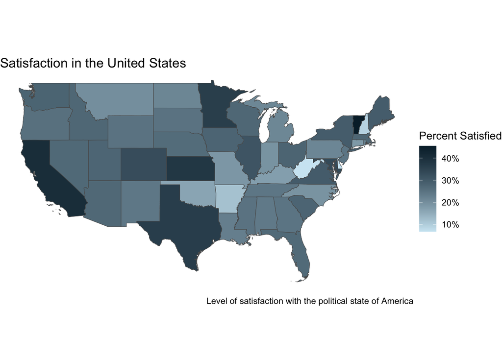

```r
## Creating the Choropleth

(vis01 %>%
  ggplot() +
  geom_sf(aes(
    fill = percent)) +
  scale_fill_gradient(
    low = "#cfe8f3",
    high = "#062635",
    labels = scales :: percent) +
  theme_void() +
  labs(
    title = "Satisfaction in the United States",
    caption = "Level of satisfaction with the political state of America",
    fill = "Percent Satisfied")
)
```

This map shows the variation of satisfaction in the US with how things are generally going politically in 2014, and can further show polarization. These results can be compared to visualization four as the West region seems to have a greater satisfaction than the Northeast, and the map shows generally that people are more satisfied with the political state of the US in the west half of the map over the east. Though more research is needed to prove a causal relationship between the two, one can see visually that there is possible correlation.

```r
library(ggplot2)

## Cleaning and Compiling Data
(vis02 <- data %>%
  select(respid, cregion, qa1) %>%
  filter(qa1 != 9, !is.na(cregion), !is.na(qa1)) %>%
    mutate(
      happy = case_when(
        qa1 == 1 ~ "Very Happy",
        qa1 == 2 ~ "Somewhat Happy",
        qa1 == 3 ~ "Not Too Happy"),
      region = case_when(
        cregion == 1 ~ "Northeast",
        cregion == 2 ~ "Midwest",
        cregion == 3 ~ "South",
        cregion == 4 ~ "West")) %>%
    group_by(happy, region) %>%
    summarize(count = n())
)
```

```
# A tibble: 12 × 3
# Groups:   happy [3]
   happy          region    count
   <chr>          <chr>     <int>
 1 Not Too Happy  Midwest     102
 2 Not Too Happy  Northeast    89
 3 Not Too Happy  South       163
 4 Not Too Happy  West        110
 5 Somewhat Happy Midwest     411
 6 Somewhat Happy Northeast   321
 7 Somewhat Happy South       661
 8 Somewhat Happy West        381
 9 Very Happy     Midwest     198
10 Very Happy     Northeast   184
11 Very Happy     South       397
12 Very Happy     West        269
```

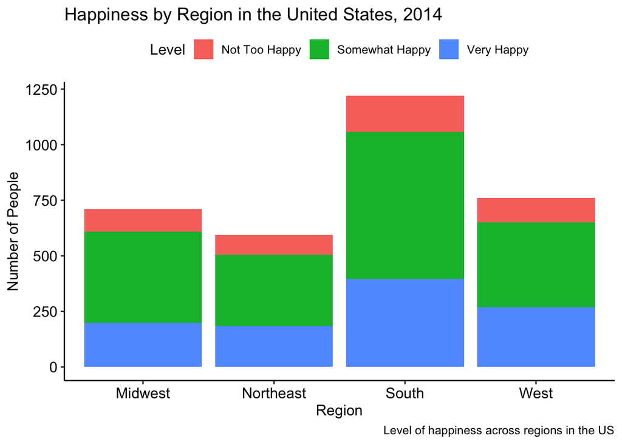

```r
## Creating the Stacked Bar Chart

(vis02 %>%
  ggplot(
    aes(fill = happy, x = region, y = count)) +
  geom_bar(stat = "identity", position = "stack") +
  labs(
    title = "Happiness by Region in the United States, 2014",
    x = "Region",
    y = "Number of People",
    caption = "Level of happiness across regions in the US",
    fill = "Level")
)
```

This stacked bar chart shows the different levels of happiness across the number of people per region. When looking at the proportions of this graph, we can see that those in the South and West are happiest, and those in the Midwest and Northeast are the least happy. This could be due to the fact that there is more political variation in the Midwest and Northeast than in the South and West, though, more research will need to be conducted to prove this relationship as causal instead of correlative.